# Untitled

shilpa gupta

10/24/2021

## ANOVA

**Analysis of Variance** technique partitions the total variability in the sample data into component parts - variance explained by the regression line and the residual variance unexplained by the regression line.

ANOVA F-Test $F_0 = MS_R/MS_E$ Under null hypothesis $F_0$ has F-distribution with $(a-1)$ and $a(n-1)$ degrees of freedom

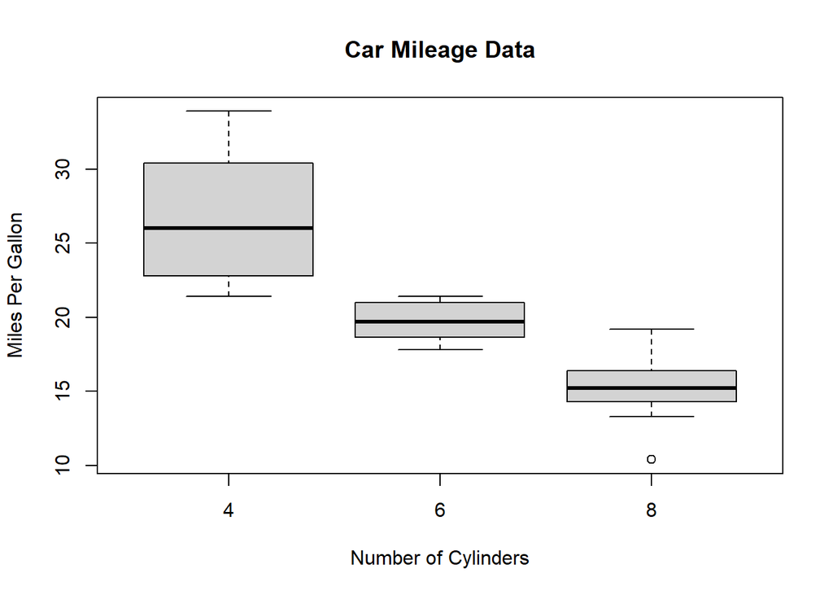

```r
boxplot(mpg~as.factor(cyl),data=mtcars, main="Car Mileage Data",
   xlab="Number of Cylinders", ylab="Miles Per Gallon")
```

```r
fit = aov(mpg~as.factor(cyl), data=mtcars)
anova(fit)
```

```
## Analysis of Variance Table
##
## Response: mpg
##                Df Sum Sq Mean Sq F value    Pr(>F)
## as.factor(cyl)  2 824.78  412.39  39.697 4.979e-09 ***
## Residuals      29 301.26   10.39
## ---
## Signif. codes:  0 '***' 0.001 '**' 0.01 '*' 0.05 '.' 0.1 ' ' 1
```

## Correlation among Input Variables

Are the input variables correlated? Lets start with computing and visualizing the correlation matrix

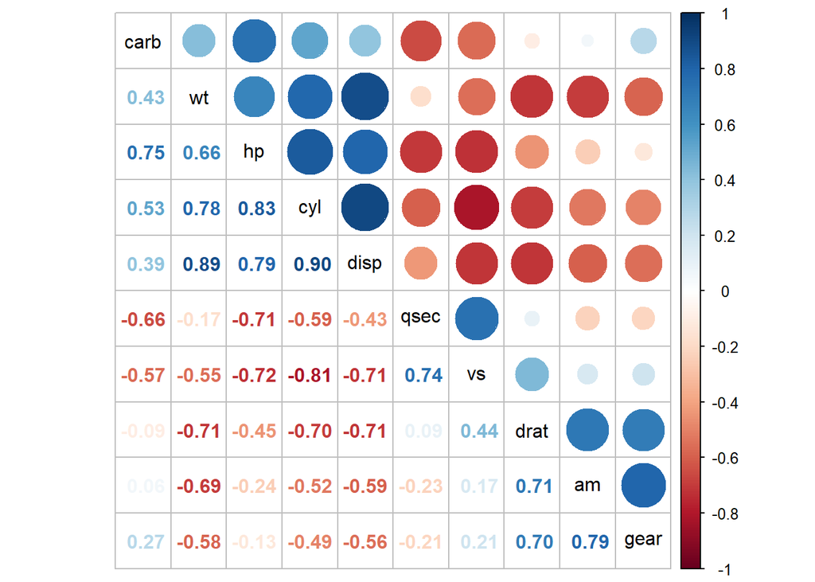

```r
library(corrplot)
library(tidyverse)
library(car)
corrplot.mixed(cor(mtcars[,-1]), order="hclust", tl.col="black")
```

## Regression

Building empirical models

Before we begin regression modeling, we need to check the distribution of the response we are trying to predict

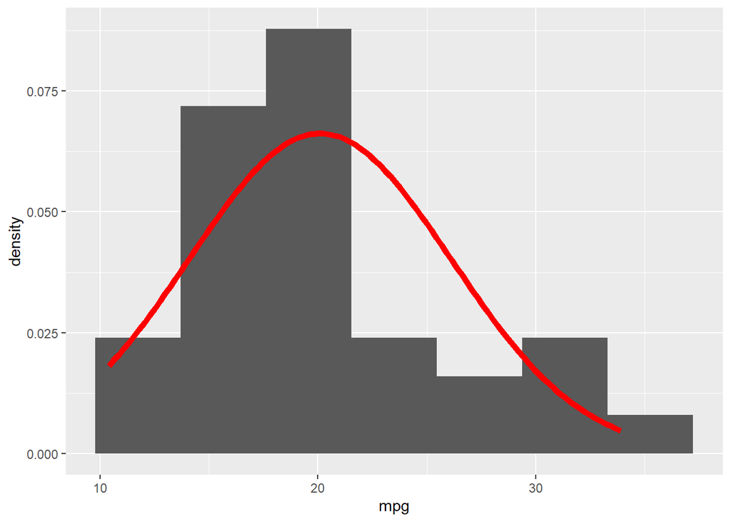

```r
ggplot(data = mtcars, aes(mpg)) + geom_histogram(mapping = aes(x = mpg, y = stat(density)), bins = 7) +
   stat_function(
    fun = dnorm,
    args = list(mean = mean(mtcars$mpg), sd = sd(mtcars$mpg)),
    lwd = 2,
    col = 'red')
```

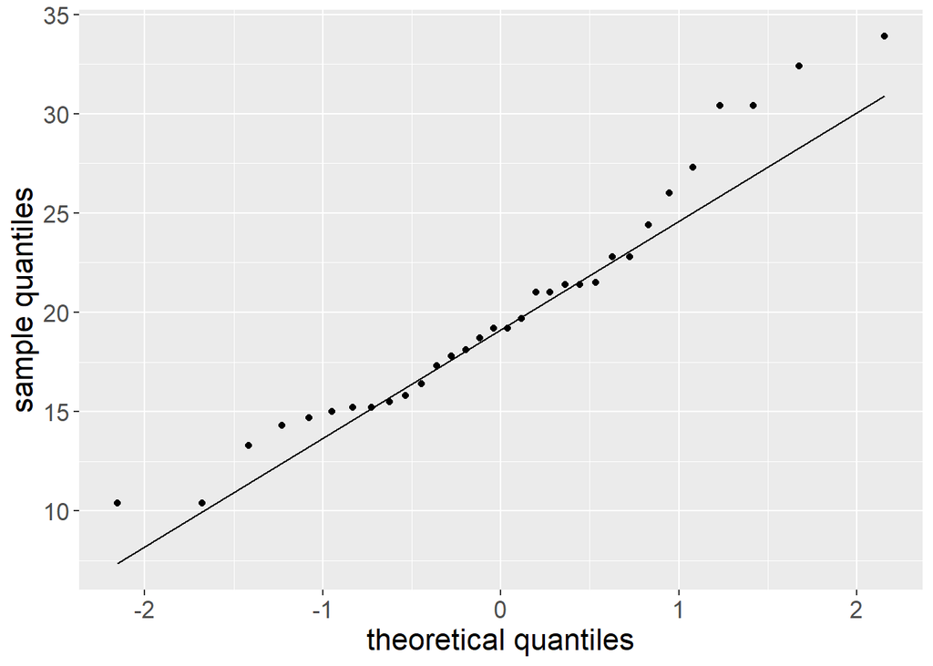

```r
mpg <- ggplot(data = mtcars, aes(sample = mpg))
mpg + stat_qq(distribution = stats::qnorm) + stat_qq_line() +
  labs(y = 'sample quantiles', x = 'theoretical quantiles') +
  theme(text = element_text(size = 16))
```

Some of the questions we are trying to address with performing regression analysis Q: Is the model statistically different from zero (p-value < 0.05)? Q: Is the model predictive (Adjusted R-squared > 0.95).

Fit a full model

```r
fit = lm(mpg~wt+ as.factor(cyl), data=mtcars)
summary(fit)
```

```
##
## Call:
## lm(formula = mpg ~ wt + as.factor(cyl), data = mtcars)
##
## Residuals:
##     Min      1Q  Median      3Q     Max
## -4.5890 -1.2357 -0.5159  1.3845  5.7915
##
## Coefficients:
##                 Estimate Std. Error t value Pr(>|t|)
## (Intercept)      33.9908     1.8878  18.006  < 2e-16 ***
## wt               -3.2056     0.7539  -4.252 0.000213 ***
## as.factor(cyl)6  -4.2556     1.3861  -3.070 0.004718 **
## as.factor(cyl)8  -6.0709     1.6523  -3.674 0.000999 ***
## ---
## Signif. codes:  0 '***' 0.001 '**' 0.01 '*' 0.05 '.' 0.1 ' ' 1
##
## Residual standard error: 2.557 on 28 degrees of freedom
## Multiple R-squared:  0.8374, Adjusted R-squared:   0.82
## F-statistic: 48.08 on 3 and 28 DF,  p-value: 3.594e-11
```

### Residual Analysis

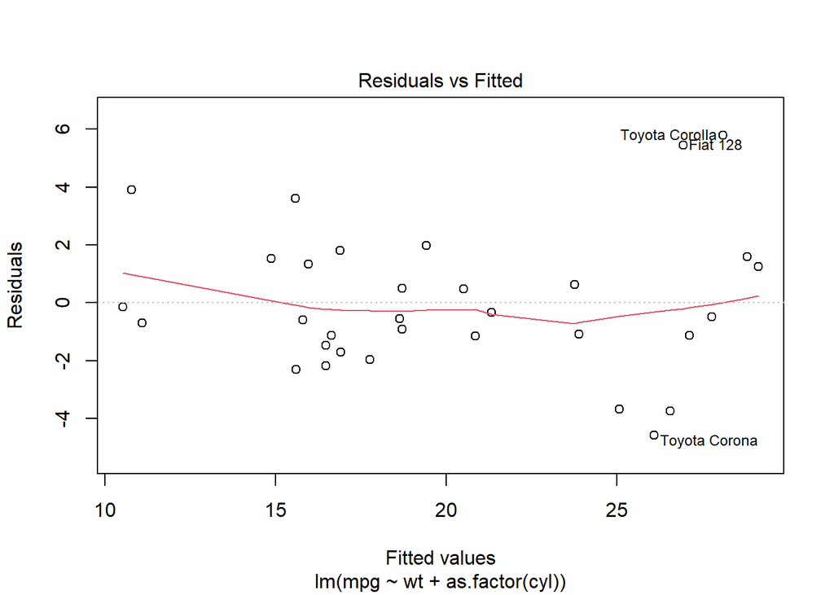

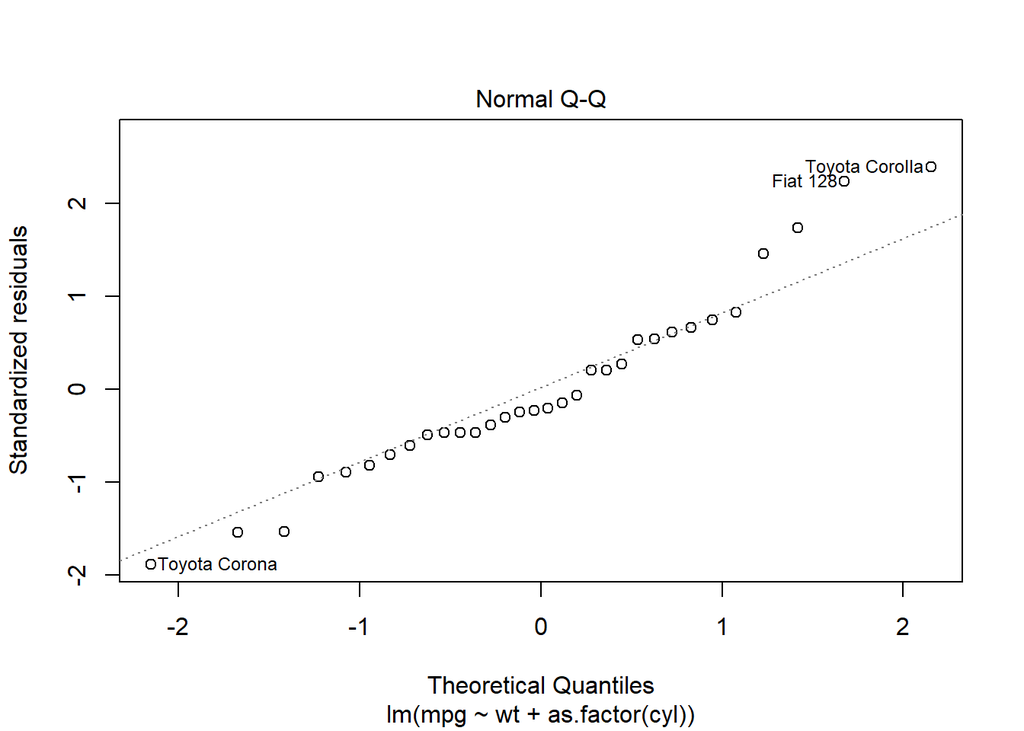

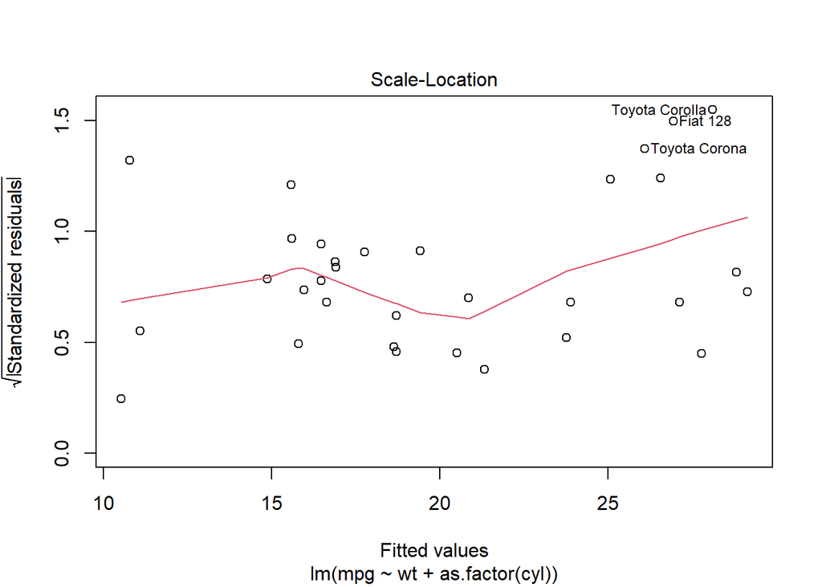

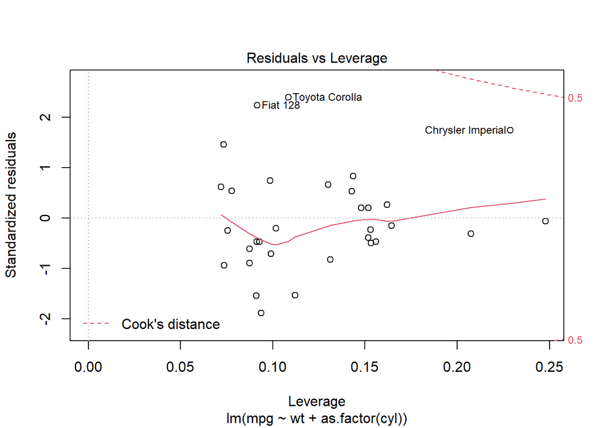

```r
plot(fit)
```

## Other Diagnostic functions

Other functions you can try:

- coefficients(fit) # model coefficients
- confint(fit, level=0.95) # CIs for model parameters
- fitted(fit) # predicted values
- residuals(fit) # residuals
- anova(fit) # anova table
- vcov(fit) # covariance matrix for model parameters
- influence(fit) # regression diagnostics

```r
confint(fit, level=0.95)
```

```
##                     2.5 %    97.5 %
## (Intercept)     30.123824 37.857764
## wt              -4.749898 -1.661328
## as.factor(cyl)6 -7.094824 -1.416341
## as.factor(cyl)8 -9.455418 -2.686301
```

## Additional Regression Diagnostics

```r
# Assessing Outliers
outlierTest(fit) # Bonferonni p-value for most extreme obs
```

```
## No Studentized residuals with Bonferroni p < 0.05
## Largest |rstudent|:
##                rstudent unadjusted p-value Bonferroni p
## Toyota Corolla 2.643017           0.013511      0.43236
```

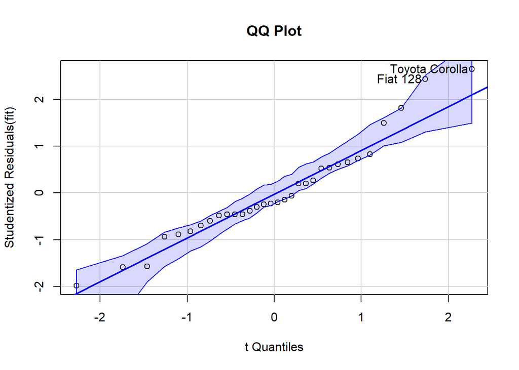

```
##       Fiat 128 Toyota Corolla
##             18             20
```

```r
qqPlot(fit, main="QQ Plot") #qq plot for studentized resid
```

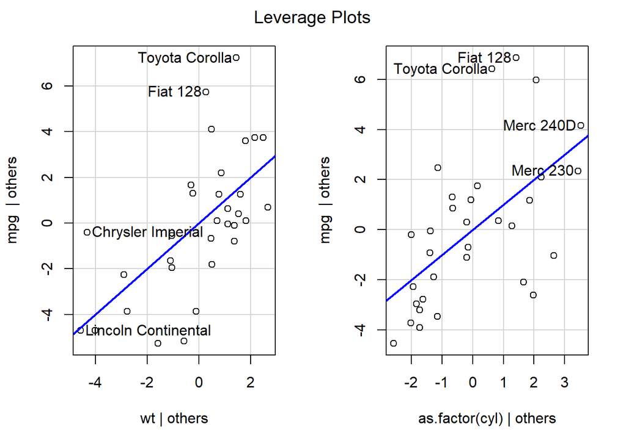

```r
leveragePlots(fit) # leverage plots
```